# Ex3

### Essential Libraries

Let us begin by importing the essential Python Libraries.

> NumPy : Library for Numeric Computations in Python  
> Pandas : Library for Data Acquisition and Preparation  
> Matplotlib : Low-level library for Data Visualization  
> Seaborn : Higher-level library for Data Visualization

```python
# Basic Libraries
import numpy as np
import pandas as pd
import seaborn as sb
import matplotlib.pyplot as plt # we only need pyplot
sb.set() # set the default Seaborn style for graphics
```

```python
trndata = pd.read_csv('train.csv')
trndata.head()
```

|  | Id | MSSubClass | MSZoning | LotFrontage | LotArea | Street | Alley | LotShape | LandContour | Utilities | ... | PoolArea | PoolQC | Fence | MiscFeature | MiscVal | MoSold | YrSold | SaleType | SaleCondition | SalePrice |
| --- | --- | --- | --- | --- | --- | --- | --- | --- | --- | --- | --- | --- | --- | --- | --- | --- | --- | --- | --- | --- | --- |
| 0 | 1 | 60 | RL | 65.0 | 8450 | Pave | NaN | Reg | Lvl | AllPub | ... | 0 | NaN | NaN | NaN | 0 | 2 | 2008 | WD | Normal | 208500 |
| 1 | 2 | 20 | RL | 80.0 | 9600 | Pave | NaN | Reg | Lvl | AllPub | ... | 0 | NaN | NaN | NaN | 0 | 5 | 2007 | WD | Normal | 181500 |
| 2 | 3 | 60 | RL | 68.0 | 11250 | Pave | NaN | IR1 | Lvl | AllPub | ... | 0 | NaN | NaN | NaN | 0 | 9 | 2008 | WD | Normal | 223500 |
| 3 | 4 | 70 | RL | 60.0 | 9550 | Pave | NaN | IR1 | Lvl | AllPub | ... | 0 | NaN | NaN | NaN | 0 | 2 | 2006 | WD | Abnorml | 140000 |
| 4 | 5 | 60 | RL | 84.0 | 14260 | Pave | NaN | IR1 | Lvl | AllPub | ... | 0 | NaN | NaN | NaN | 0 | 12 | 2008 | WD | Normal | 250000 |

5 rows × 81 columns

```python
print("Data type : ", type(trndata))
print("Data dims : ", trndata.shape)
```

```
Data type :  <class 'pandas.core.frame.DataFrame'>
Data dims :  (1460, 81)
```

```python
print(trndata.dtypes)
```

```
Id                 int64
MSSubClass         int64
MSZoning          object
LotFrontage      float64
LotArea            int64
                  ...
MoSold             int64
YrSold             int64
SaleType          object
SaleCondition     object
SalePrice          int64
Length: 81, dtype: object
```

```python
# Information about the Variables
trndata.info()
```

```
<class 'pandas.core.frame.DataFrame'>
RangeIndex: 1460 entries, 0 to 1459
Data columns (total 81 columns):
 #   Column         Non-Null Count  Dtype
---  ------         --------------  -----
 0   Id             1460 non-null   int64
 1   MSSubClass     1460 non-null   int64
 2   MSZoning       1460 non-null   object
 3   LotFrontage    1201 non-null   float64
 4   LotArea        1460 non-null   int64
 5   Street         1460 non-null   object
 6   Alley          91 non-null     object
 7   LotShape       1460 non-null   object
 8   LandContour    1460 non-null   object
 9   Utilities      1460 non-null   object
```

[output cut: 73 more lines]

```python
houseNumData = pd.DataFrame(trndata[['LotArea', 'GrLivArea', 'TotalBsmtSF', 'GarageArea', 'SalePrice']])
```

```python
houseNumData.head(20)
```

|  | LotArea | GrLivArea | TotalBsmtSF | GarageArea | SalePrice |
| --- | --- | --- | --- | --- | --- |
| 0 | 8450 | 1710 | 856 | 548 | 208500 |
| 1 | 9600 | 1262 | 1262 | 460 | 181500 |
| 2 | 11250 | 1786 | 920 | 608 | 223500 |
| 3 | 9550 | 1717 | 756 | 642 | 140000 |
| 4 | 14260 | 2198 | 1145 | 836 | 250000 |
| 5 | 14115 | 1362 | 796 | 480 | 143000 |
| 6 | 10084 | 1694 | 1686 | 636 | 307000 |
| 7 | 10382 | 2090 | 1107 | 484 | 200000 |
| 8 | 6120 | 1774 | 952 | 468 | 129900 |
| 9 | 7420 | 1077 | 991 | 205 | 118000 |
| 10 | 11200 | 1040 | 1040 | 384 | 129500 |
| 11 | 11924 | 2324 | 1175 | 736 | 345000 |
| 12 | 12968 | 912 | 912 | 352 | 144000 |
| 13 | 10652 | 1494 | 1494 | 840 | 279500 |
| 14 | 10920 | 1253 | 1253 | 352 | 157000 |
| 15 | 6120 | 854 | 832 | 576 | 132000 |
| 16 | 11241 | 1004 | 1004 | 480 | 149000 |
| 17 | 10791 | 1296 | 0 | 516 | 90000 |
| 18 | 13695 | 1114 | 1114 | 576 | 159000 |
| 19 | 7560 | 1339 | 1029 | 294 | 139000 |

## Description of the house data

```python
houseNumData.describe()
```

|  | LotArea | GrLivArea | TotalBsmtSF | GarageArea | SalePrice |
| --- | --- | --- | --- | --- | --- |
| count | 1460.000000 | 1460.000000 | 1460.000000 | 1460.000000 | 1460.000000 |
| mean | 10516.828082 | 1515.463699 | 1057.429452 | 472.980137 | 180921.195890 |
| std | 9981.264932 | 525.480383 | 438.705324 | 213.804841 | 79442.502883 |
| min | 1300.000000 | 334.000000 | 0.000000 | 0.000000 | 34900.000000 |
| 25% | 7553.500000 | 1129.500000 | 795.750000 | 334.500000 | 129975.000000 |
| 50% | 9478.500000 | 1464.000000 | 991.500000 | 480.000000 | 163000.000000 |
| 75% | 11601.500000 | 1776.750000 | 1298.250000 | 576.000000 | 214000.000000 |
| max | 215245.000000 | 5642.000000 | 6110.000000 | 1418.000000 | 755000.000000 |

```python
SP = pd.DataFrame(trndata['SalePrice'])
SP.head(10)
```

|  | SalePrice |
| --- | --- |
| 0 | 208500 |
| 1 | 181500 |
| 2 | 223500 |
| 3 | 140000 |
| 4 | 250000 |
| 5 | 143000 |
| 6 | 307000 |
| 7 | 200000 |
| 8 | 129900 |
| 9 | 118000 |

```python
SP.info()
```

```
<class 'pandas.core.frame.DataFrame'>
RangeIndex: 1460 entries, 0 to 1459
Data columns (total 1 columns):
 #   Column     Non-Null Count  Dtype
---  ------     --------------  -----
 0   SalePrice  1460 non-null   int64
dtypes: int64(1)
memory usage: 11.5 KB
```

## Graph of SalePrice

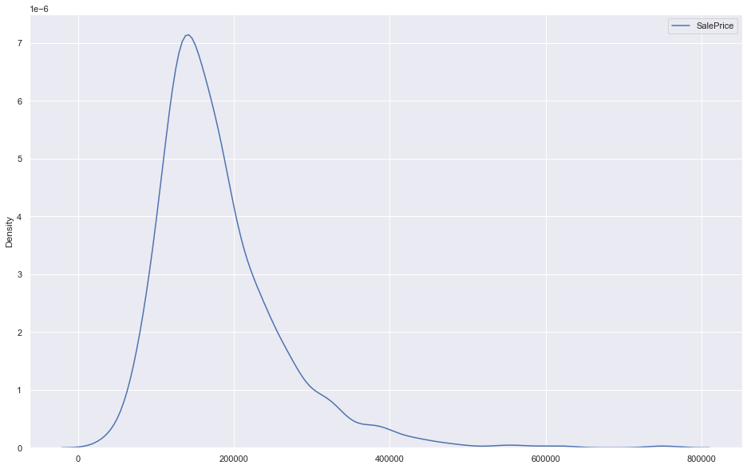

```python
f = plt.figure(figsize=(16, 10))
sb.kdeplot(data = SP)
```

From the data, we can see that the graph is positively skewed

```python
skewSP = SP.skew(axis=0)
print(skewSP)
```

```
SalePrice    1.882876
dtype: float64
```

SalePrice has a skewness value of +1.882876

```python
skewHND = houseNumData.skew(axis =0)
print(skewHND)
```

```
LotArea        12.207688
GrLivArea       1.366560
TotalBsmtSF     1.524255
GarageArea      0.179981
SalePrice       1.882876
dtype: float64
```

GarageArea is the least skewed with only 0.17 value and LotArea is the most skewed with 12.2

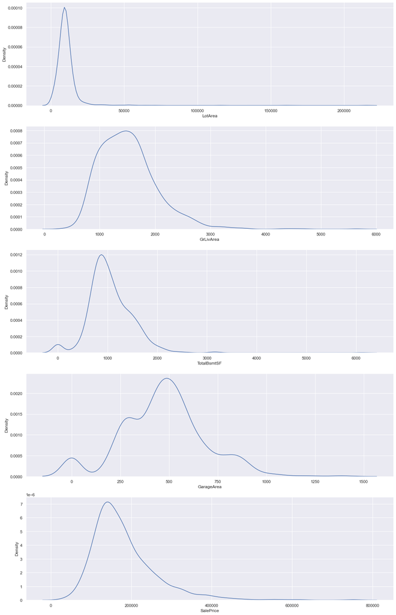

```python
# Draw the distributions of all variables
f, axes = plt.subplots(5, 1, figsize=(18, 30))

count = 0
for var in houseNumData[0:1]:
    #f = plt.figure(figsize=(16, 10))
    sb.kdeplot(data = houseNumData[var],ax=axes[count])
    count += 1
```

```python
# Calculate the complete  correlation matrix
houseNumData.corr()
```

|  | LotArea | GrLivArea | TotalBsmtSF | GarageArea | SalePrice |
| --- | --- | --- | --- | --- | --- |
| LotArea | 1.000000 | 0.263116 | 0.260833 | 0.180403 | 0.263843 |
| GrLivArea | 0.263116 | 1.000000 | 0.454868 | 0.468997 | 0.708624 |
| TotalBsmtSF | 0.260833 | 0.454868 | 1.000000 | 0.486665 | 0.613581 |
| GarageArea | 0.180403 | 0.468997 | 0.486665 | 1.000000 | 0.623431 |
| SalePrice | 0.263843 | 0.708624 | 0.613581 | 0.623431 | 1.000000 |

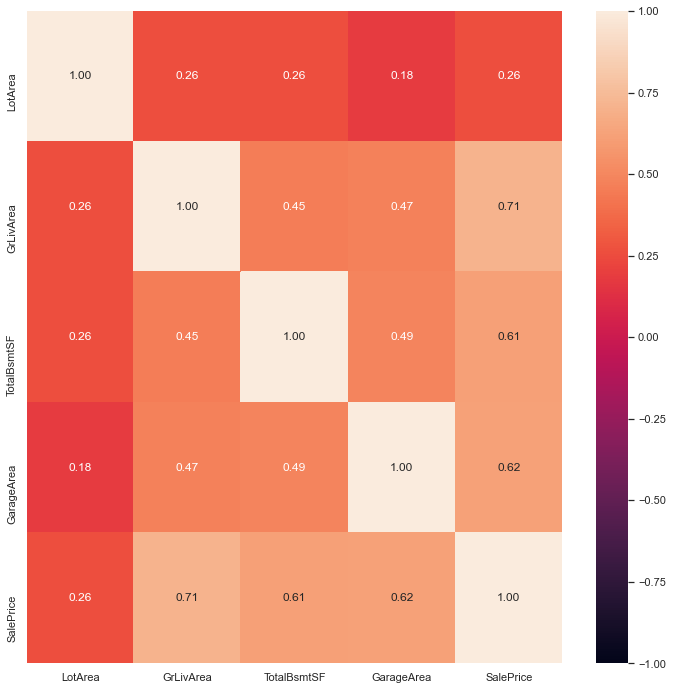

```python
# Heatmap of the Correlation Matrix
f = plt.figure(figsize=(12, 12))
sb.heatmap(houseNumData.corr(), vmin = -1, vmax = 1, annot = True, fmt = ".2f")
```

GarageArea with LotArea has the least correlation while GrLivArea and SalePrice has the most correlation. In general, most variables are relatively not correlated with a value of less than 0.5

## Concating the most correlated variables(SP and GrLivArea)

```python
GLA = pd.DataFrame(trndata['GrLivArea'])
GLA.head(10)
```

|  | GrLivArea |
| --- | --- |
| 0 | 1710 |
| 1 | 1262 |
| 2 | 1786 |
| 3 | 1717 |
| 4 | 2198 |
| 5 | 1362 |
| 6 | 1694 |
| 7 | 2090 |
| 8 | 1774 |
| 9 | 1077 |

```python
# Create a joint dataframe by concatenating the two variables
jointDF = pd.concat([GLA, SP], axis = 1).reindex(GLA.index)
jointDF
```

|  | GrLivArea | SalePrice |
| --- | --- | --- |
| 0 | 1710 | 208500 |
| 1 | 1262 | 181500 |
| 2 | 1786 | 223500 |
| 3 | 1717 | 140000 |
| 4 | 2198 | 250000 |
| ... | ... | ... |
| 1455 | 1647 | 175000 |
| 1456 | 2073 | 210000 |
| 1457 | 2340 | 266500 |
| 1458 | 1078 | 142125 |
| 1459 | 1256 | 147500 |

1460 rows × 2 columns

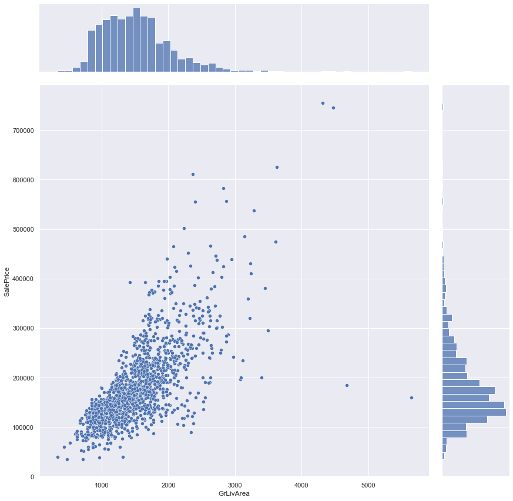

```python
# Draw jointplot of the two variables in the joined dataframe
sb.jointplot(data = jointDF, x = "GrLivArea", y = "SalePrice", height = 12)
```

From the graph,it is easy to see a clear correlation, especially at the lower price areas that as GLA increases, SP increases too. However, around the 2.5k mark on GLA, the points starts to be more scattered and unpredictable hence concluding that from 0 to 2.5k GLA, it is accurate for prediction of SP however after that, it is not accurate

## Prob2

```python
houseCatData = pd.DataFrame(trndata[['MSSubClass', 'Neighborhood', 'BldgType', 'OverallQual']])
houseCatData.head(10)
```

|  | MSSubClass | Neighborhood | BldgType | OverallQual |
| --- | --- | --- | --- | --- |
| 0 | 60 | CollgCr | 1Fam | 7 |
| 1 | 20 | Veenker | 1Fam | 6 |
| 2 | 60 | CollgCr | 1Fam | 7 |
| 3 | 70 | Crawfor | 1Fam | 7 |
| 4 | 60 | NoRidge | 1Fam | 8 |
| 5 | 50 | Mitchel | 1Fam | 5 |
| 6 | 20 | Somerst | 1Fam | 8 |
| 7 | 60 | NWAmes | 1Fam | 7 |
| 8 | 50 | OldTown | 1Fam | 7 |
| 9 | 190 | BrkSide | 2fmCon | 5 |

```
Number of MSSubClass : 15
20     536
60     299
50     144
120     87
30      69
160     63
70      60
80      58
90      52
190     30
85      20
75      16
45      12
180     10
40       4
Name: MSSubClass, dtype: int64
```

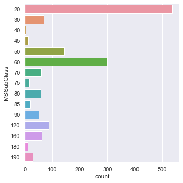

```python
# MSSubClass in the Dataset
print("Number of MSSubClass :", len(trndata["MSSubClass"].unique()))

# count in each MSSubClass
print(trndata["MSSubClass"].value_counts())
sb.catplot(y = "MSSubClass", data = trndata, kind = "count")
```

From the plot, its easy to identify that the MSSubClass for 20 and 60 dominates the market with the highest count

#### use.astype('category') to change int to cat

```python
MSSC = pd.DataFrame(houseCatData['MSSubClass'])
MSSC.astype('category').dtypes
```

```
MSSubClass    category
dtype: object
```

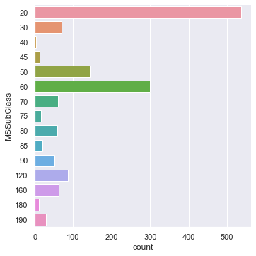

```python
sb.catplot(y = "MSSubClass", data = MSSC, kind = "count")
```

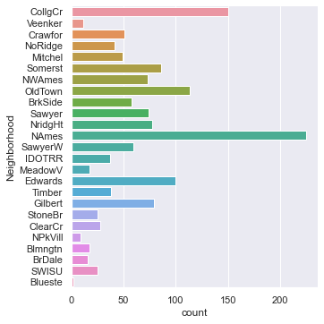

```python
# Neighborhood data
NB = pd.DataFrame(houseCatData['Neighborhood'])
NB.astype('category').dtypes
sb.catplot(y = "Neighborhood", data = NB, kind = "count")
```

```python
OvQ = pd.DataFrame(houseCatData['OverallQual'])
OvQ.astype('category').dtypes
```

```
OverallQual    category
dtype: object
```

```
Overall Qual and MSSubClass : 1460
```

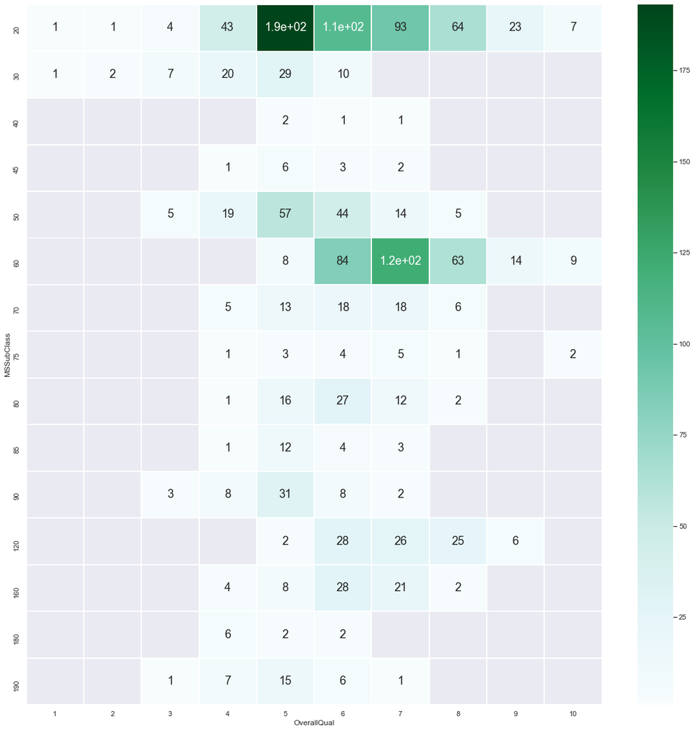

```python
dualtype_data = houseCatData[houseCatData["OverallQual"].isnull() == False]
print("Overall Qual and MSSubClass :", len(dualtype_data))


# Distribution of the MSSC & OvQ
f = plt.figure(figsize=(20, 20))
sb.heatmap(dualtype_data.groupby(['MSSubClass', 'OverallQual']).size().unstack(),
           linewidths = 1, annot = True, annot_kws = {"size": 18}, cmap = "BuGn")
```

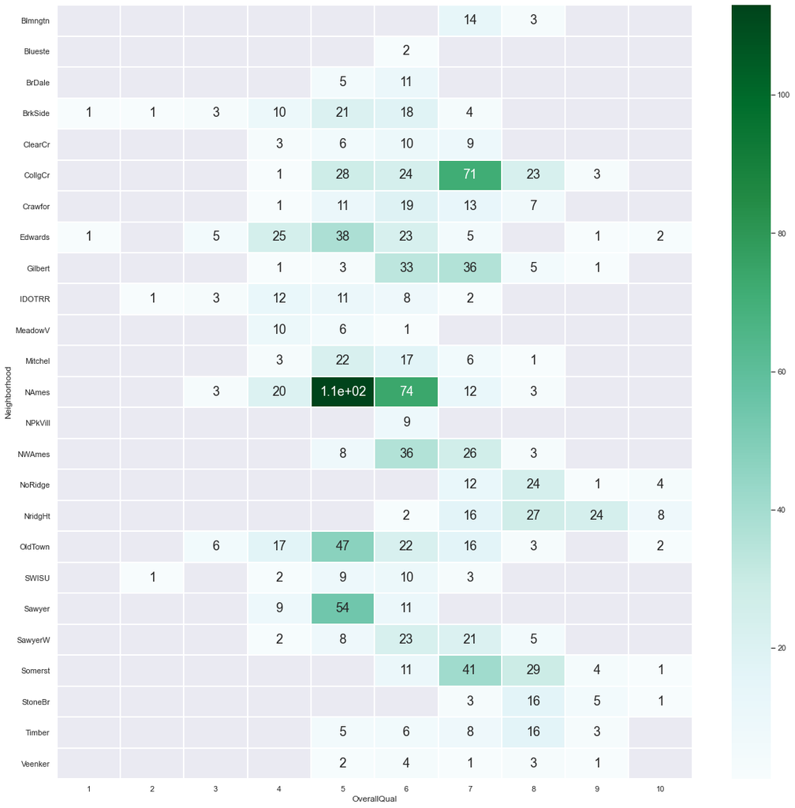

```python
# Distribution of NB & OvQ
f = plt.figure(figsize=(20, 20))
sb.heatmap(dualtype_data.groupby(['Neighborhood', 'OverallQual']).size().unstack(),
           linewidths = 1, annot = True, annot_kws = {"size": 18}, cmap = "BuGn")
```

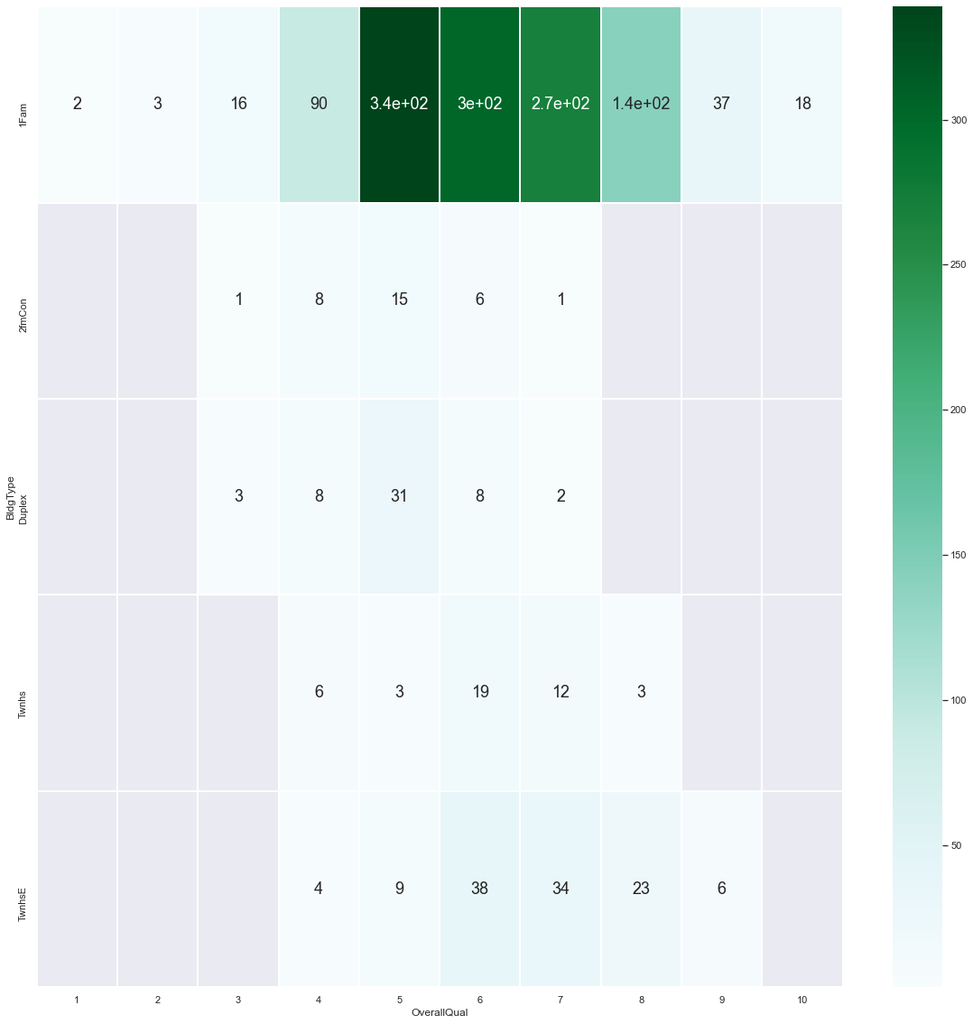

```python
# Distribution of the Two Types
f = plt.figure(figsize=(20, 20))
sb.heatmap(dualtype_data.groupby(['BldgType', 'OverallQual']).size().unstack(),
           linewidths = 1, annot = True, annot_kws = {"size": 18}, cmap = "BuGn")
```

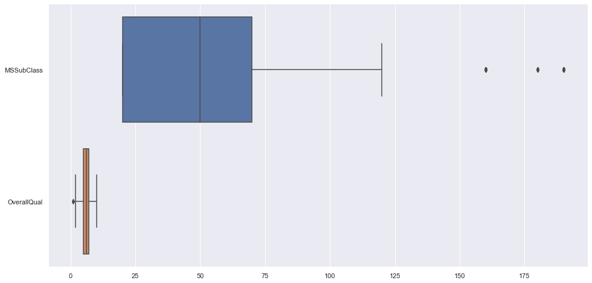

```python
#boxplot = trndata.boxplot(row = SP, column =houseCatData)
#ax = sb.boxplot(x=houseCatData, y="SalePrice", data=trndata)
# Draw the Boxplots of all variables
f = plt.figure(figsize=(16, 8))
sb.boxplot(data = houseCatData, orient = "h")
```